# Ejercicio: Lectura y Limpieza de Datos de Café

2026-05-03

```r
library(tidyverse)
library(lubridate)
```

```r
datos <- readr::read_csv("coffee_ratings.csv")
cat(sprintf("Dimensiones del dataset: %d filas × %d columnas\n", nrow(datos), ncol(datos)))
```

```
## Dimensiones del dataset: 1339 filas × 43 columnas
```

## Actividad 0: Análisis de valores faltantes del objeto `datos`

**Procedimiento:**

Se utilizó `readr::read_csv()` para cargar el dataset, función del paquete `readr` (parte de `tidyverse`) que detecta automáticamente los tipos de columna y retorna un `tibble`. Para el análisis de valores faltantes, las funciones clave son:

- **`is.na(datos)`**: retorna una matriz lógica (`TRUE`/`FALSE`) del mismo tamaño que `datos`, donde `TRUE` indica un valor faltante.
- **`colSums(is.na(datos))`**: suma por columna la matriz lógica anterior; como `TRUE` equivale a 1 y `FALSE` a 0, el resultado es el conteo de `NA` por variable.
- **`dplyr::filter()`**: conserva únicamente las filas que cumplen una condición — aquí, columnas con al menos un valor faltante.
- **`dplyr::arrange(desc(...))`**: ordena el data frame de mayor a menor según la columna indicada.
- **`round()`**: redondea el porcentaje a dos decimales.

**Resultados:**

```r
na_counts <- datos |> is.na() |> colSums()

resumen_na <- tibble(
  columna           = na_counts |> names(),
  valores_faltantes = na_counts |> as.integer(),
  porcentaje        = (na_counts / nrow(datos) * 100) |> round(2)
) |>
  filter(valores_faltantes > 0) |>
  arrange(desc(valores_faltantes))

resumen_na |> print(row.names = FALSE)
```

```
## # A tibble: 19 × 3
##    columna              valores_faltantes porcentaje
##    <chr>                            <int>      <dbl>
##  1 lot_number                        1063      79.4
##  2 farm_name                          359      26.8
##  3 mill                               315      23.5
##  4 producer                           231      17.2
##  5 altitude_low_meters                230      17.2
##  6 altitude_high_meters               230      17.2
##  7 altitude_mean_meters               230      17.2
##  8 altitude                           226      16.9
##  9 variety                            226      16.9
## 10 color                              218      16.3
## 11 company                            209      15.6
## 12 processing_method                  170      12.7
## 13 ico_number                         151      11.3
## 14 region                              59       4.41
## 15 harvest_year                        47       3.51
## 16 owner                                7       0.52
## 17 owner_1                              7       0.52
## 18 country_of_origin                    1       0.07
## 19 quakers                              1       0.07
```

## Actividad 1: Crear la columna `color2` a partir de `color`

**Procedimiento:**

Se creó la columna `color2` mediante el par de funciones más idiomático de `dplyr` para transformaciones condicionales:

- **`dplyr::mutate()`**: añade o modifica columnas dentro de un `tibble`/`data.frame` sin alterar las demás. Recibe expresiones que se evalúan columna por columna.
- **`dplyr::case_when()`**: equivalente vectorizado de múltiples `if/else if/else`. Cada línea es una fórmula `condición ~ valor_resultado`; la condición `is.na(color) ~ NA_character_` asigna explícitamente `NA` cuando el color original es faltante (el caso `TRUE ~ NA_character_` actúa como cláusula por defecto).
- **`is.na()`**: detecta valores `NA` en un vector.
- **`table(..., useNA = "always")`**: tabla de frecuencias cruzada que incluye los `NA` como categoría, útil para verificar el resultado.

**Resultados:**

```r
datos <- datos |>
  mutate(
    color2 = case_when(
      is.na(color)           ~ NA_character_,
      color == "Green"       ~ "#00FF66",
      color == "Bluish-Green"~ "#CCEBC5",
      color == "Blue-Green"  ~ "#BFFFFF",
      TRUE                   ~ NA_character_
    )
  )

cat("Distribución de color vs color2:\n")
```

```
## Distribución de color vs color2:
```

```r
print(table(datos$color, datos$color2, useNA = "always"))
```

```
##
##                #00FF66 #BFFFFF #CCEBC5 <NA>
##   Blue-Green         0      85       0    0
##   Bluish-Green       0       0     114    0
##   Green            870       0       0    0
##   None               0       0       0   52
##   <NA>               0       0       0  218
```

## Actividad 2: Crear la columna numérica `bag_weight2` a partir de `bag_weight`

**Procedimiento:**

La columna `bag_weight` almacena cadenas de texto como `"60 kg"` o `"100 lbs"`. Para extraer solo el valor numérico se emplearon funciones del paquete `stringr`:

- **`stringr::str_detect(string, pattern)`**: retorna un vector lógico indicando si cada elemento del vector `string` contiene el patrón regex. Se usa para identificar los valores ambiguos que tienen coma (`","`) indicando múltiples unidades.
- **`stringr::str_extract(string, pattern)`**: extrae la **primera** subcadena que coincide con el patrón regex. El patrón `"\\d+(\\.\\d+)?"` captura uno o más dígitos seguidos opcionalmente de un punto decimal y más dígitos.
- **`dplyr::if_else(condition, true, false)`**: versión estricta del `ifelse()` base que respeta los tipos de datos; asigna `NA_real_` (NA de tipo `double`) cuando la condición es verdadera (valor ambiguo).
- **`as.numeric()`**: convierte la cadena extraída a tipo numérico.

Se consideran **ambiguas** las observaciones con coma en `bag_weight` (p. ej., `"2 kg,lbs"`), ya que indican múltiples unidades sin un valor único determinable.

**Resultados:**

Se encontraron **2 observaciones ambiguas**: `"1 kg,lbs"` y `"2 kg,lbs"`, que reciben `NA` en `bag_weight2`.

```r
ambiguos_bw <- datos |>
  filter(str_detect(bag_weight, ","))

datos <- datos |>
  mutate(
    bag_weight2 = if_else(
      str_detect(bag_weight, ","),
      NA_real_,
      bag_weight |> str_extract("\\d+(\\.\\d+)?") |> as.numeric()
    )
  )

vals_ambiguos_bw <- ambiguos_bw$bag_weight |> unique()
cat(sprintf("Observaciones ambiguas en bag_weight: %d\n", nrow(ambiguos_bw)))
```

```
## Observaciones ambiguas en bag_weight: 2
```

```r
cat("Valores ambiguos únicos:", vals_ambiguos_bw, "\n")
```

```
## Valores ambiguos únicos: 2 kg,lbs 1 kg,lbs
```

## Actividad 3: Crear `method1` y `method2` a partir de `processing_method`

**Procedimiento:**

La columna `processing_method` contiene valores como `"Natural / Dry"` o `"Washed / Wet"`, separados por `"/"`. La función central es:

- **`stringr::str_match(string, pattern)`**: aplica el patrón regex al vector `string` y retorna una **matriz** donde la primera columna es la coincidencia completa y las columnas siguientes son los grupos de captura `(...)`. Devuelve `NA` en filas donde el patrón no coincide, lo que identifica automáticamente los casos ambiguos (valores sin separador o `NA`).
- El patrón `"^(.+?)\\s*/\\s*(.+)$"` usa dos grupos de captura: el primero `(.+?)` captura el texto antes de `"/"` de forma no-greedy, y el segundo `(.+)$` captura todo lo que sigue.
- **`str_trim()`**: elimina espacios al inicio y al final de las cadenas extraídas.
- **`sum(is.na(...))`**: cuenta cuántas filas no tuvieron coincidencia con el patrón.

**Resultados:**

El conteo de ambigüedades incluye las 170 filas con `NA` en `processing_method` más las filas con el valor `"Other"` (sin separador `"/"`).

```r
pm_match <- str_match(datos$processing_method, "^(.+?)\\s*/\\s*(.+)$")

datos <- datos |>
  mutate(
    method1 = pm_match[, 2] |> str_trim(),
    method2 = pm_match[, 3] |> str_trim()
  )

n_ambiguos_pm  <- pm_match[, 1] |> is.na() |> sum()
vals_ambiguos_pm <- datos$processing_method[pm_match[, 1] |> is.na()] |> unique()
cat(sprintf("Observaciones ambiguas en processing_method: %d\n", n_ambiguos_pm))
```

```
## Observaciones ambiguas en processing_method: 196
```

```r
cat("Valores únicos ambiguos:", vals_ambiguos_pm, "\n")
```

```
## Valores únicos ambiguos: NA Other
```

## Actividad 4: Crear `expiration_day`, `expiration_month` y `expiration_year`

**Procedimiento:**

La columna `expiration` sigue el formato inglés de fecha ordinal: `"Month DDth, YYYY"` (p. ej., `"April 3rd, 2016"`). Se utiliza `str_match()` con grupos de captura para extraer los tres componentes en una sola operación:

- **Patrón regex**: `"^(\\w+)\\s+(\\d{1,2})(?:st|nd|rd|th),\\s+(\\d{4})$"`
  - `(\\w+)` — grupo 1: nombre del mes (una o más letras/dígitos/guión bajo).
  - `(\\d{1,2})` — grupo 2: día de 1 o 2 dígitos.
  - `(?:st|nd|rd|th)` — sufijo ordinal sin captura (`(?:...)` es un grupo no-capturante).
  - `(\\d{4})` — grupo 3: año de exactamente 4 dígitos.
- **`as.integer()`**: convierte los grupos de día y año (cadenas) a entero.
- Las filas donde el patrón **no coincide** y `expiration` no es `NA` se consideran **ambiguas**.

**Resultados:**

El formato de `expiration` es muy consistente en todo el dataset, por lo que se esperan muy pocas o ninguna observación ambigua.

```r
exp_match <- str_match(
  datos$expiration,
  "^(\\w+)\\s+(\\d{1,2})(?:st|nd|rd|th),\\s+(\\d{4})$"
)

datos <- datos |>
  mutate(
    expiration_month = exp_match[, 2],
    expiration_day   = exp_match[, 3] |> as.integer(),
    expiration_year  = exp_match[, 4] |> as.integer()
  )

n_ambiguos_exp <- (!is.na(datos$expiration) & is.na(exp_match[, 2])) |> sum()
cat(sprintf("Observaciones ambiguas en expiration: %d\n", n_ambiguos_exp))
```

```
## Observaciones ambiguas en expiration: 0
```

```r
cat("\nMuestra de las nuevas columnas:\n")
```

```
##
## Muestra de las nuevas columnas:
```

```r
datos |>
  select(expiration, expiration_day, expiration_month, expiration_year) |>
  head(8) |>
  print()
```

```
## # A tibble: 8 × 4
##   expiration           expiration_day expiration_month expiration_year
##   <chr>                         <int> <chr>                      <int>
## 1 April 3rd, 2016                   3 April                       2016
## 2 April 3rd, 2016                   3 April                       2016
## 3 May 31st, 2011                   31 May                         2011
## 4 March 25th, 2016                 25 March                       2016
## 5 April 3rd, 2016                   3 April                       2016
## 6 September 3rd, 2014               3 September                   2014
## 7 September 17th, 2013             17 September                   2013
## 8 September 2nd, 2011               2 September                   2011
```

## Actividad 5: Crear `harvest_mes` y `harvest_anio` a partir de `harvest_year`

**Procedimiento:**

La columna `harvest_year` presenta formatos muy heterogéneos: años simples (`"2016"`), rangos de años (`"2016/2017"`), mes + año (`"March 2010"`), rangos de meses (`"August to December"`), valores con temporada (`"Fall 2009"`) y valores malformados (`"4T72010"`, `"TEST"`). Para separar correctamente el mes del año se utilizaron **dos expresiones regulares independientes** en lugar de un simple `split`:

- `harvest_anio`: extrae el **último año de 4 dígitos** (patrón `19xx` o `20xx`) encontrado en el texto, usando `stringr::str_extract_all()` + `purrr::map_chr()` para tomar el último elemento del vector de coincidencias.
- `harvest_mes`: extrae el **primer nombre de mes** (inglés o español) o temporada encontrado en el texto, usando `stringr::str_extract()` con `regex(..., ignore_case = TRUE)`.

Ambas columnas reciben `NA` cuando su respectivo patrón no encuentra coincidencia. Se considera **ambigua** cualquier fila donde no es posible extraer el año.

**Resultados:**

Con este enfoque, valores como `"2014"` quedan correctamente como `harvest_mes=NA` y `harvest_anio="2014"`, y valores como `"March 2010"` quedan como `harvest_mes="March"` y `harvest_anio="2010"`. Las observaciones ambiguas se reducen a los casos donde genuinamente no hay año: `NA` originales, rangos de meses sin año (`"Abril - Julio"`, `"May-August"`) y valores malformados (`"TEST"`, `"mmm"`).

```r
patron_anio <- "\\b(?:19|20)\\d{2}\\b"
patron_mes  <- paste0(
  "\\b(?:January|February|March|April|May|June|July|August|September|October|November|December",
  "|Jan|Feb|Mar|Apr|Jun|Jul|Aug|Sep|Sept|Oct|Nov|Dec",
  "|Enero|Febrero|Marzo|Abril|Mayo|Junio|Julio|Agosto|Septiembre|Octubre|Noviembre|Diciembre",
  "|Spring|Summer|Fall|Winter)\\b"
)

datos <- datos |>
  mutate(
    harvest_anio = map_chr(
      str_extract_all(harvest_year, patron_anio),
      ~ { v <- .x[!is.na(.x)]; if (length(v) == 0) NA_character_ else tail(v, 1) }
    ),
    harvest_mes = str_extract(harvest_year, regex(patron_mes, ignore_case = TRUE))
  )

n_ambiguos_hy   <- datos$harvest_anio |> is.na() |> sum()
n_na_originales <- datos$harvest_year |> is.na() |> sum()
n_sin_anio      <- (is.na(datos$harvest_anio) & !is.na(datos$harvest_year)) |> sum()

cat(sprintf("Observaciones ambiguas en harvest_year: %d\n", n_ambiguos_hy))
```

```
## Observaciones ambiguas en harvest_year: 64
```

```r
cat(sprintf("  · NaN originales en harvest_year:        %d\n", n_na_originales))
```

```
##   · NaN originales en harvest_year:        47
```

```r
cat(sprintf("  · Sin año extraíble (valor presente):    %d\n", n_sin_anio))
```

```
##   · Sin año extraíble (valor presente):    17
```

```r
cat("\nValores únicos sin año extraíble (no NA):\n")
```

```
##
## Valores únicos sin año extraíble (no NA):
```

```r
datos$harvest_year[is.na(datos$harvest_anio) & !is.na(datos$harvest_year)] |>
  unique() |>
  sort() |>
  print()
```

```
##  [1] "08/09 crop"            "4T/10"                 "4T72010"
##  [4] "Abril - Julio"         "August to December"    "January Through April"
##  [7] "May-August"            "Mayo a Julio"          "mmm"
## [10] "TEST"
```

```r
cat("\nMuestra de las nuevas columnas:\n")
```

```
##
## Muestra de las nuevas columnas:
```

```r
datos |>
  select(harvest_year, harvest_mes, harvest_anio) |>
  head(10) |>
  print()
```

```
## # A tibble: 10 × 3
##    harvest_year harvest_mes harvest_anio
##    <chr>        <chr>       <chr>
##  1 2014         <NA>        2014
##  2 2014         <NA>        2014
##  3 <NA>         <NA>        <NA>
##  4 2014         <NA>        2014
##  5 2014         <NA>        2014
##  6 2013         <NA>        2013
##  7 2012         <NA>        2012
##  8 March 2010   March       2010
##  9 March 2010   March       2010
## 10 2014         <NA>        2014
```

## Actividad 6: Visualización de `total_cup_points`, `acidity` y `color2`

**Procedimiento:**

Se elaboró un diagrama de dispersión con `ggplot2`. Las funciones y capas clave son:

- **`ggplot(data, aes(...))`**: inicializa el gráfico definiendo los mapeos estéticos globales (`x`, `y`, `color`). La función `aes()` mapea columnas del data frame a propiedades visuales.
- **`geom_point()`**: capa de puntos para el diagrama de dispersión. Parámetros usados: `alpha` (transparencia), `size` (tamaño), `shape` (forma).
- **`scale_color_identity(guide = "legend", ...)`**: le indica a ggplot2 que los valores de la columna `color2` **son colores literales** (códigos hex), no categorías a mapear a una paleta. Sin esta escala, ggplot no sabría interpretar `"#00FF66"` como un color. El parámetro `guide = "legend"` activa la leyenda; `breaks` y `labels` definen qué valores mostrar y con qué etiquetas.
- **`drop_na()`**: elimina filas con `NA` en las columnas indicadas.
- **`labs()`**: define títulos de ejes, título principal y título de leyenda.
- **`theme_bw()`**: tema de fondo blanco con cuadrícula gris, adecuado para publicaciones.

**Resultados:**

El gráfico muestra los tres colores literales del grano. Se aprecia una correlación positiva moderada entre acidez y puntuación total, con poca diferencia entre colores.

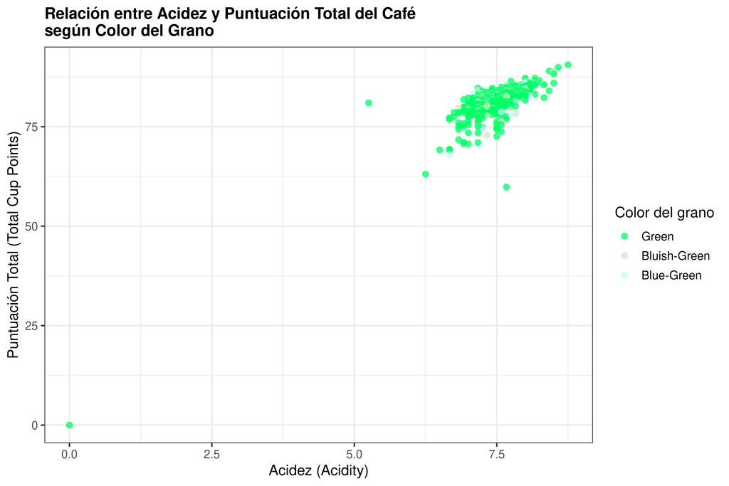

```r
df6 <- datos |> drop_na(color2, total_cup_points, acidity)

ggplot(df6, aes(x = acidity, y = total_cup_points, color = color2)) +
  geom_point(alpha = 0.75, size = 2.5, shape = 16) +
  scale_color_identity(
    guide  = "legend",
    breaks = c("#00FF66", "#CCEBC5", "#BFFFFF"),
    labels = c("Green", "Bluish-Green", "Blue-Green")
  ) +
  labs(
    x     = "Acidez (Acidity)",
    y     = "Puntuación Total (Total Cup Points)",
    title = "Relación entre Acidez y Puntuación Total del Café\nsegún Color del Grano",
    color = "Color del grano"
  ) +
  theme_bw(base_size = 13) +
  theme(
    plot.title   = element_text(face = "bold", size = 14),
    legend.position = "right"
  )
```

## Actividad 7: Visualización de densidad de `bag_weight2` por `species`

**Procedimiento:**

Se elaboró un gráfico de densidad (estimación por núcleo, KDE) con las siguientes capas y funciones:

- **`geom_density()`**: capa que estima y dibuja la función de densidad de probabilidad de la variable continua. Parámetros: `fill` (color de relleno del área bajo la curva), `alpha` (transparencia del relleno), `linewidth` (grosor de la línea de la curva).
- **`scale_fill_brewer()` / `scale_color_brewer()`**: aplican paletas de color de ColorBrewer (diseñadas para ser perceptualmente distinguibles). Cuando se usan `fill` y `color` a la vez, ambas escalas deben especificarse para que la leyenda sea única.
- **`dplyr::filter(bag_weight2 < 2000)`**: excluye valores atípicos extremos que distorsionarían la escala horizontal.
- **`drop_na()`**: elimina filas con `NA` en las columnas de interés.

**Resultados:**

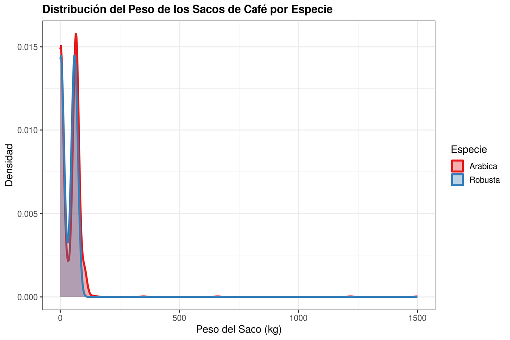

```r
df7 <- datos |>
  drop_na(bag_weight2, species) |>
  filter(bag_weight2 < 2000)

ggplot(df7, aes(x = bag_weight2, fill = species, color = species)) +
  geom_density(alpha = 0.35, linewidth = 1.2) +
  scale_fill_brewer(palette = "Set1") +
  scale_color_brewer(palette = "Set1") +
  labs(
    x     = "Peso del Saco (kg)",
    y     = "Densidad",
    title = "Distribución del Peso de los Sacos de Café por Especie",
    fill  = "Especie",
    color = "Especie"
  ) +
  theme_bw(base_size = 13) +
  theme(plot.title = element_text(face = "bold", size = 14))
```

## Actividad 8: Fecha de expiración vs `total_cup_points` (México, Brasil, Colombia, Guatemala)

**Procedimiento:**

Se construyó una serie de tiempo para los cuatro países. Las funciones importantes son:

- **`dplyr::filter(country_of_origin %in% paises)`**: el operador `%in%` selecciona filas cuyo valor pertenece al vector `paises`, equivalente a múltiples condiciones `==` unidas por `|`.
- **`setNames(1:12, month_levels)`**: crea un vector nombrado que mapea nombres de mes (carácter) a su número ordinal; se usa para construir la fecha.
- **`lubridate::ymd()`**: convierte cadenas en formato `"YYYY-MM-DD"` a objetos `Date`. Es más robusto que `as.Date()` para formatos no ambiguos.
- **`paste(..., sep = "-")`**: concatena los componentes año, mes, día en la cadena esperada por `ymd()`.
- **`dplyr::group_by()` + `summarise()`**: agrupa las filas por fecha y país, y calcula la media de `total_cup_points` por grupo.
- **`geom_line()` + `geom_point()`**: capas para trazar la serie de tiempo con marcadores en cada observación.
- **`scale_x_date(date_labels, date_breaks)`**: formatea el eje temporal con etiquetas de fecha (`%b %Y` = “Abr 2016”) y define el intervalo entre marcas.

**Resultados:**

El gráfico muestra la puntuación media por fecha de expiración para cada país, revelando tendencias y disponibilidad temporal diferenciada por región.

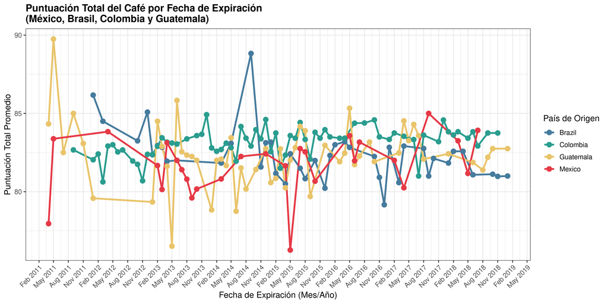

```r
paises <- c("Mexico", "Brazil", "Colombia", "Guatemala")

month_levels <- c("January","February","March","April","May","June",
                  "July","August","September","October","November","December")
month_num <- setNames(1:12, month_levels)

palette_paises <- c(
  "Mexico"    = "#E63946",
  "Brazil"    = "#457B9D",
  "Colombia"  = "#2A9D8F",
  "Guatemala" = "#E9C46A"
)

df8 <- datos |>
  filter(country_of_origin %in% paises) |>
  drop_na(expiration_year, expiration_month, total_cup_points) |>
  mutate(
    mes_num   = month_num[expiration_month],
    fecha_exp = paste(expiration_year, mes_num, "01", sep = "-") |> ymd()
  ) |>
  group_by(fecha_exp, country_of_origin) |>
  summarise(total_cup_points = mean(total_cup_points, na.rm = TRUE), .groups = "drop") |>
  arrange(fecha_exp)

ggplot(df8, aes(x = fecha_exp, y = total_cup_points,
                color = country_of_origin, group = country_of_origin)) +
  geom_line(linewidth = 1.2) +
  geom_point(size = 3) +
  scale_color_manual(values = palette_paises) +
  scale_x_date(date_labels = "%b %Y", date_breaks = "3 months") +
  labs(
    x     = "Fecha de Expiración (Mes/Año)",
    y     = "Puntuación Total Promedio",
    title = "Puntuación Total del Café por Fecha de Expiración\n(México, Brasil, Colombia y Guatemala)",
    color = "País de Origen"
  ) +
  theme_bw(base_size = 12) +
  theme(
    axis.text.x  = element_text(angle = 45, hjust = 1),
    plot.title   = element_text(face = "bold", size = 14)
  )
```

## Actividad 9: Mes de expiración vs altitudes (México, Brasil, Colombia, Guatemala — 2016 y 2017)

**Procedimiento:**

Se usó el paradigma *tidy data* para transformar las tres columnas de altitud en filas. Las funciones clave son:

- **`tidyr::pivot_longer(cols, names_to, values_to)`**: transforma el data frame de formato ancho (*wide*) a largo (*long*), convirtiendo las columnas indicadas en `cols` en dos columnas: `names_to` (nombre de la variable) y `values_to` (su valor). Esto permite graficar las tres altitudes como una sola variable categórica `tipo_altitud`.
- **`factor(..., levels = ...)`** / **`forcats::fct_relevel()`**: establece el orden de las categorías del factor `expiration_month` para que el eje horizontal respete el orden cronológico (enero a diciembre) en lugar del orden alfabético.
- **`ggplot2::facet_wrap(~ variable)`**: divide el gráfico en paneles (facetas) según los valores de `variable`; aquí crea un panel por año de expiración.
- **`stat_summary(fun = mean, geom = "line")`**: calcula la media de `y` por grupo y la dibuja como línea, sin necesidad de agregar previamente. Más flexible que `geom_line()` directo cuando hay múltiples observaciones por punto x.
- **`scale_color_brewer(palette = "Dark2")`**: paleta cualitativa con colores bien diferenciables para las tres altitudes.

**Resultados:**

La visualización de dos paneles compara cómo varía la altitud de cultivo por mes de expiración en 2016 y 2017, distinguiendo la altitud mínima, media y máxima.

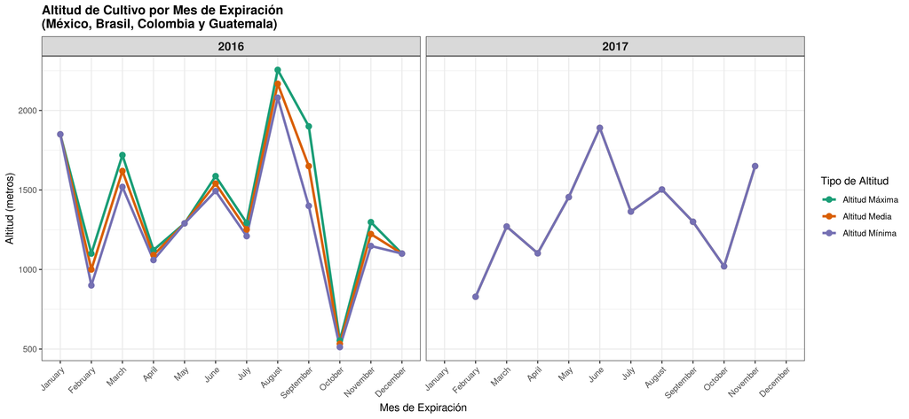

```r
month_levels <- c("January","February","March","April","May","June",
                  "July","August","September","October","November","December")
paises <- c("Mexico", "Brazil", "Colombia", "Guatemala")

df9 <- datos |>
  filter(
    country_of_origin %in% paises,
    expiration_year %in% c(2016L, 2017L)
  ) |>
  drop_na(expiration_month,
          altitude_low_meters, altitude_mean_meters, altitude_high_meters) |>
  mutate(
    expiration_month = factor(expiration_month, levels = month_levels)
  ) |>
  pivot_longer(
    cols      = c(altitude_low_meters, altitude_mean_meters, altitude_high_meters),
    names_to  = "tipo_altitud",
    values_to = "altitud_metros"
  ) |>
  mutate(
    tipo_altitud = case_when(
      tipo_altitud == "altitude_low_meters"  ~ "Altitud Mínima",
      tipo_altitud == "altitude_mean_meters" ~ "Altitud Media",
      tipo_altitud == "altitude_high_meters" ~ "Altitud Máxima"
    )
  )

ggplot(df9, aes(x = expiration_month, y = altitud_metros,
                color = tipo_altitud, group = tipo_altitud)) +
  stat_summary(fun = mean, geom = "line",  linewidth = 1.2) +
  stat_summary(fun = mean, geom = "point", size = 2.5) +
  facet_wrap(~ expiration_year, nrow = 1) +
  scale_color_brewer(palette = "Dark2") +
  labs(
    x     = "Mes de Expiración",
    y     = "Altitud (metros)",
    title = "Altitud de Cultivo por Mes de Expiración\n(México, Brasil, Colombia y Guatemala)",
    color = "Tipo de Altitud"
  ) +
  theme_bw(base_size = 11) +
  theme(
    axis.text.x  = element_text(angle = 45, hjust = 1),
    plot.title   = element_text(face = "bold", size = 13),
    strip.text   = element_text(face = "bold", size = 12)
  )
```

## Actividad 10: Visualización de `aftertaste`, `acidity`, `body` y `species` en un mismo canvas

**Procedimiento:**

Se usó exclusivamente `tidyverse` (sin paquetes adicionales). La estrategia combina `pivot_longer()` y `facet_wrap()` para mostrar las tres variables en un mismo canvas:

- **`tidyr::pivot_longer(cols, names_to, values_to)`**: transforma el data frame de formato ancho a largo. Las tres columnas numéricas (`aftertaste`, `acidity`, `body`) se apilan en una sola columna `valor`, y sus nombres pasan a la columna categórica `variable`. Esto permite tratar las tres métricas como facetas de un mismo gráfico.
- **`dplyr::case_when()`**: renombra los valores de `variable` al español para las etiquetas del gráfico.
- **`geom_violin(trim = FALSE)`**: dibuja la distribución completa de cada variable para cada especie como una figura simétrica en forma de violín. `trim = FALSE` extiende las colas hasta los valores extremos reales.
- **`geom_boxplot()`**: superpuesto al violín, muestra la mediana, los cuartiles y los valores atípicos. El argumento `width` controla el ancho del boxplot para que no tape el violín.
- **`ggplot2::facet_wrap(~ variable, scales = "free_y")`**: divide el canvas en un panel por cada valor de `variable` (uno por métrica). `scales = "free_y"` permite que cada panel tenga su propia escala vertical, ya que las tres variables tienen rangos similares pero distintos.
- **`scale_fill_brewer(palette = "Set1")`**: aplica una paleta cualitativa distinguible para las especies.

**Resultados:**

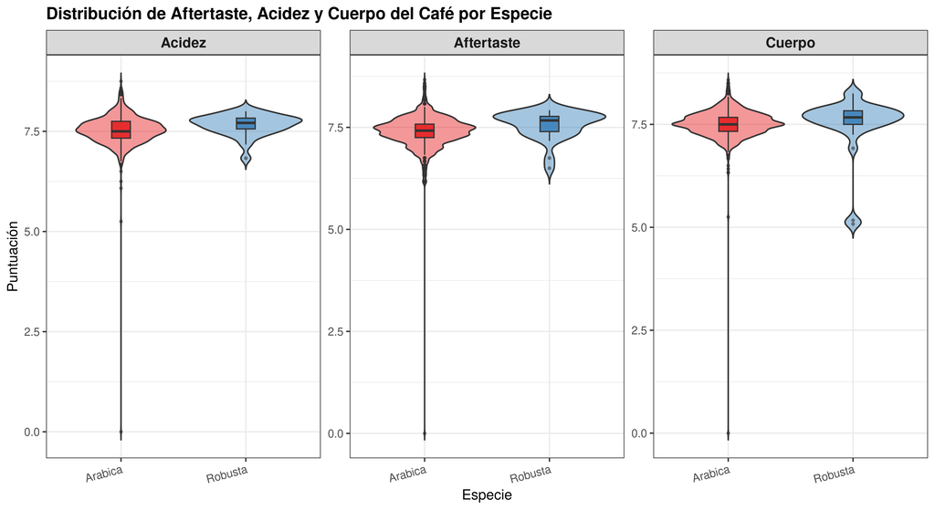

```r
df10 <- datos |>
  select(aftertaste, acidity, body, species) |>
  drop_na() |>
  pivot_longer(
    cols      = c(aftertaste, acidity, body),
    names_to  = "variable",
    values_to = "valor"
  ) |>
  mutate(
    variable = case_when(
      variable == "aftertaste" ~ "Aftertaste",
      variable == "acidity"    ~ "Acidez",
      variable == "body"       ~ "Cuerpo"
    )
  )

ggplot(df10, aes(x = species, y = valor, fill = species)) +
  geom_violin(alpha = 0.45, trim = FALSE, linewidth = 0.6) +
  geom_boxplot(width = 0.15, alpha = 0.85, outlier.size = 0.8,
               outlier.alpha = 0.5, linewidth = 0.5) +
  facet_wrap(~ variable, scales = "free_y", nrow = 1) +
  scale_fill_brewer(palette = "Set1") +
  labs(
    x     = "Especie",
    y     = "Puntuación",
    title = "Distribución de Aftertaste, Acidez y Cuerpo del Café por Especie",
    fill  = "Especie"
  ) +
  theme_bw(base_size = 12) +
  theme(
    plot.title   = element_text(face = "bold", size = 14),
    strip.text   = element_text(face = "bold", size = 12),
    axis.text.x  = element_text(angle = 15, hjust = 1),
    legend.position = "none"
  )
```